# Social_impact_evaluation

VCRA

2025-03-05

# **Informe: Evaluación de Impacto Social Proyectos**

##### **Introducción**: Este análisis tiene como objetivo evaluar el impacto social de varios proyectos en Chile, centrándose en tres niveles clave:

##### - **Línea Base Social**: Características de la población afectada.

##### - **Variables de Impacto**: Efectos directos de los proyectos en las comunidades.

##### - **Variables de Mitigación de Riesgos**: Medidas para reducir impactos negativos.

##### **Propósito**: Comprender cómo estas variables influyen en la percepción y el éxito de los proyectos, proporcionando insights valiosos para futuras iniciativas.

### Instalación de paquetes y liberías

```r
# Verificar e instalar paquetes si no están instalados
if (!require("tidyverse")) install.packages("tidyverse")
```

```r
if (!require("ggplot2")) install.packages("ggplot2")
if (!require("corrplot")) install.packages("corrplot")
if (!require("dplyr")) install.packages("dplyr")
if (!require("psych")) install.packages("psych")
if (!require("readxl")) install.packages("readxl")
if (!require("RColorBrewer")) install.packages("RColorBrewer")
if (!require("scales")) install.packages("scales")
if (!require("car")) install.packages("car")
# Cargar librerías

library(tidyverse)
library(ggplot2)
library(corrplot)
library(dplyr)
library(psych)
library(readxl)
library(RColorBrewer)
library(scales)
library (car)
```

### Carga de Base de datos

```r
# Cargar archivo XLS
df <- read_excel("EIS/eis.xlsx")

# Ver las primeras lineas del dataset
head(df)
```

| ID_proyecto | ID_com | Nombre_proyecto | Sector | Región | Población_total_region | Pob_indígena | Porcentaje_rural | Tasa_desempleo | Num_actores_clave | Experiencias_industrias_previas | Confianza_instituciones | Participación_ciudadana | Conocimiento_proyecto | Confianza_responsables | Organización_comunitaria | Opinion_proyecto | Principales_vulnerabilidades | Riesgo_desplazamiento | Impacto_cohesión_social | Cambio_empleo_local | Percepción_ambiental | Impacto_seguridad_servicios | Impacto_calidad_vida | Conflictos_potenciales | Satisfacción_mitigación | Cumplimiento_compromisos |
| --- | --- | --- | --- | --- | --- | --- | --- | --- | --- | --- | --- | --- | --- | --- | --- | --- | --- | --- | --- | --- | --- | --- | --- | --- | --- | --- |
| 239 | 182 | Forestal AndesVerde | Forestal | Biobío | 1600000 | 0.18 | 0.22 | 0.0942 | 1 | Sí | 2 | 3 | 5 | 2 | Medio | Negativa | Población rural | Bajo | Negativo | Aumento | 1 | Negativo | Neutro | Sí | 3 | Medio |
| 239 | 49 | Forestal AndesVerde | Forestal | Biobío | 1600000 | 0.18 | 0.22 | 0.0942 | 9 | Sí | 1 | 3 | 3 | 4 | Medio | Negativa | Adulto Mayor | Bajo | Negativo | Sin cambio | 2 | Neutro | Neutro | Sí | 3 | Bajo |
| 239 | 61 | Forestal AndesVerde | Forestal | Biobío | 1600000 | 0.18 | 0.22 | 0.0942 | 8 | Sí | 3 | 2 | 1 | 2 | Medio | Positiva | Mujeres | Bajo | Neutro | Sin cambio | 1 | Negativo | Neutro | No | 4 | Medio |
| 239 | 197 | Forestal AndesVerde | Forestal | Biobío | 1600000 | 0.18 | 0.22 | 0.0942 | 9 | Sí | 4 | 3 | 1 | 4 | Bajo | Positiva | Migrantes | Bajo | Negativo | Disminución | 2 | Negativo | Positivo | No | 1 | Alto |
| 239 | 104 | Forestal AndesVerde | Forestal | Biobío | 1600000 | 0.18 | 0.22 | 0.0942 | 7 | Sí | 3 | 3 | 2 | 3 | Medio | Positiva | Adulto Mayor | Bajo | Neutro | Aumento | 2 | Positivo | Neutro | No | 4 | Medio |
| 239 | 89 | Forestal AndesVerde | Forestal | Biobío | 1600000 | 0.18 | 0.22 | 0.0942 | 5 | Sí | 5 | 2 | 2 | 2 | Medio | Positiva | Adulto Mayor | Bajo | Negativo | Aumento | 2 | Neutro | Neutro | No | 2 | Bajo |

```r
# Revisión detallada del dataset
glimpse(df)
```

```
## Rows: 137
## Columns: 27
## $ ID_proyecto                     <dbl> 239, 239, 239, 239, 239, 239, 239, 239…
## $ ID_com                          <dbl> 182, 49, 61, 197, 104, 89, 57, 120, 10…
## $ Nombre_proyecto                 <chr> "Forestal AndesVerde", "Forestal Andes…
## $ Sector                          <chr> "Forestal", "Forestal", "Forestal", "F…
## $ Región                          <chr> "Biobío", "Biobío", "Biobío", "Biobío"…
## $ Población_total_region          <dbl> 1600000, 1600000, 1600000, 1600000, 16…
## $ Pob_indígena                    <dbl> 0.18, 0.18, 0.18, 0.18, 0.18, 0.18, 0.…
## $ Porcentaje_rural                <dbl> 0.22, 0.22, 0.22, 0.22, 0.22, 0.22, 0.…
## $ Tasa_desempleo                  <dbl> 0.0942, 0.0942, 0.0942, 0.0942, 0.0942…
## $ Num_actores_clave               <dbl> 1, 9, 8, 9, 7, 5, 4, 9, 8, 5, 1, 4, 6,…
## $ Experiencias_industrias_previas <chr> "Sí", "Sí", "Sí", "Sí", "Sí", "Sí", "S…
## $ Confianza_instituciones         <dbl> 2, 1, 3, 4, 3, 5, 2, 1, 3, 4, 5, 4, 4,…
## $ Participación_ciudadana         <dbl> 3, 3, 2, 3, 3, 2, 2, 2, 2, 3, 1, 1, 2,…
## $ Conocimiento_proyecto           <dbl> 5, 3, 1, 1, 2, 2, 5, 3, 3, 3, 3, 3, 3,…
## $ Confianza_responsables          <dbl> 2, 4, 2, 4, 3, 2, 5, 5, 4, 1, 3, 2, 3,…
## $ Organización_comunitaria        <chr> "Medio", "Medio", "Medio", "Bajo", "Me…
## $ Opinion_proyecto                <chr> "Negativa", "Negativa", "Positiva", "P…
## $ Principales_vulnerabilidades    <chr> "Población rural", "Adulto Mayor", "Mu…
## $ Riesgo_desplazamiento           <chr> "Bajo", "Bajo", "Bajo", "Bajo", "Bajo"…
## $ Impacto_cohesión_social         <chr> "Negativo", "Negativo", "Neutro", "Neg…
## $ Cambio_empleo_local             <chr> "Aumento", "Sin cambio", "Sin cambio",…
## $ Percepción_ambiental            <dbl> 1, 2, 1, 2, 2, 2, 2, 1, 2, 3, 2, 2, 3,…
## $ Impacto_seguridad_servicios     <chr> "Negativo", "Neutro", "Negativo", "Neg…
## $ Impacto_calidad_vida            <chr> "Neutro", "Neutro", "Neutro", "Positiv…
## $ Conflictos_potenciales          <chr> "Sí", "Sí", "No", "No", "No", "No", "S…
## $ Satisfacción_mitigación         <dbl> 3, 3, 4, 1, 4, 2, 3, 1, 1, 3, 5, 5, 2,…
## $ Cumplimiento_compromisos        <chr> "Medio", "Bajo", "Medio", "Alto", "Med…
```

### Revisión data frame

```r
## Verificar valores nulos
colSums(is.na(df))
```

```
##                     ID_proyecto                          ID_com
##                               0                               0
##                 Nombre_proyecto                          Sector
##                               0                               0
##                          Región          Población_total_region
##                               0                               0
##                    Pob_indígena                Porcentaje_rural
##                               0                               0
##                  Tasa_desempleo               Num_actores_clave
##                               0                               0
## Experiencias_industrias_previas         Confianza_instituciones
##                               0                               0
##         Participación_ciudadana           Conocimiento_proyecto
##                               0                               0
##          Confianza_responsables        Organización_comunitaria
##                               0                               0
##                Opinion_proyecto    Principales_vulnerabilidades
##                               0                               0
##           Riesgo_desplazamiento         Impacto_cohesión_social
##                               0                               0
##             Cambio_empleo_local            Percepción_ambiental
##                               0                               0
##     Impacto_seguridad_servicios            Impacto_calidad_vida
##                               0                               0
##          Conflictos_potenciales         Satisfacción_mitigación
##                               0                               0
##        Cumplimiento_compromisos
##                               0
```

```r
## Eliminación de valores nulos si es necesario
df <- df %>% drop_na()  # Eliminar filas con valores NA
```

## **Análisis Linea Base Social**

##### *Se presenta un análisis de las variables de Linea Base Social, particularmente las variables relacionadas con la región donde se ubica el Proyecto en relación a la Opinión del Proyecto.*

### **Resumen estadístico**

```r
descriptivos <- df %>%
  select(Población_total_region, Pob_indígena, Porcentaje_rural, Tasa_desempleo) %>%
  psych::describe()

print(descriptivos)
```

```
##                        vars   n       mean         sd  median    trimmed
## Población_total_region    1 137 1973722.63 2593296.51 9.0e+05 1545945.95
## Pob_indígena              2 137       0.15       0.07 1.5e-01       0.15
## Porcentaje_rural          3 137       0.25       0.16 3.5e-01       0.25
## Tasa_desempleo            4 137       0.08       0.01 8.0e-02       0.08
##                              mad   min     max   range  skew kurtosis        se
## Población_total_region 444780.00 1e+05 7.5e+06 7.4e+06  1.58     0.68 221560.27
## Pob_indígena                0.07 5e-02 2.5e-01 2.0e-01 -0.14    -1.12      0.01
## Porcentaje_rural            0.15 2e-02 4.5e-01 4.3e-01 -0.22    -1.61      0.01
## Tasa_desempleo              0.01 7e-02 1.0e-01 3.0e-02 -0.12    -1.57      0.00
```

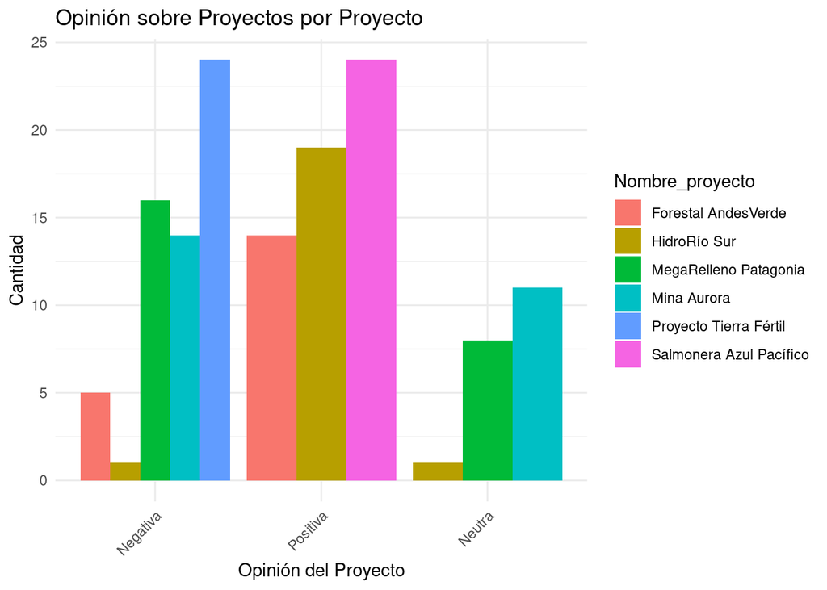

```r
ggplot(df, aes(x = fct_infreq(Opinion_proyecto), fill = Nombre_proyecto)) +  # Agrupar las opiniones
  geom_bar(position = "dodge") +  # Mejor visualización con barras separadas
  theme_minimal() +
  labs(title = "Opinión sobre Proyectos por Proyecto", x = "Opinión del Proyecto", y = "Cantidad") +
  theme(axis.text.x = element_text(angle = 45, hjust = 1))
```

### **Prueba de Hipotesis:Análisis de Correlación entre Variables de Línea Base y Opinión del Proyecto**

#### Hipótesis:

##### H0 : No existe una relación significativa entre las variables de línea base social y la opinión del proyecto.

##### H1: Existe una relación significativa entre al menos una de las variables de línea base social y la opinión del proyecto.

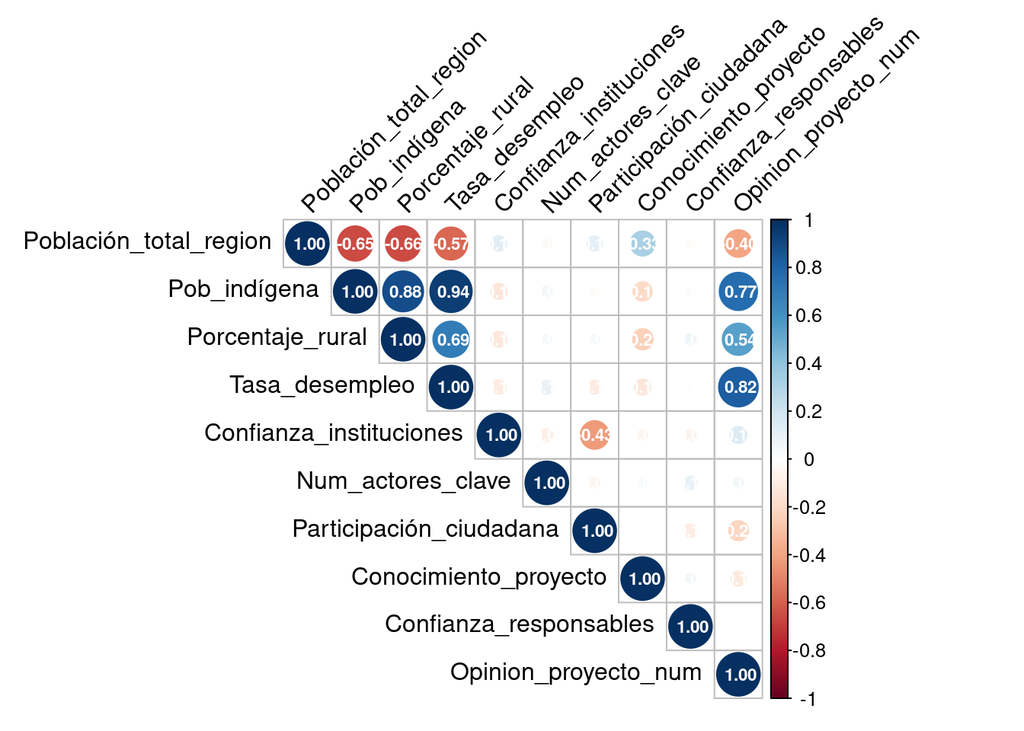

```r
df$Opinion_proyecto_num <- ifelse(df$Opinion_proyecto == "Positiva", 1,
                                  ifelse(df$Opinion_proyecto == "Neutra", 0, -1))

# Calcular la matriz de correlación

correlaciones <- cor(df[, c("Población_total_region", "Pob_indígena", "Porcentaje_rural",
                            "Tasa_desempleo", "Confianza_instituciones", "Num_actores_clave",
                            "Participación_ciudadana", "Conocimiento_proyecto",
                            "Confianza_responsables", "Opinion_proyecto_num")])

## Visualizar la matriz de correlación

corrplot(correlaciones, method = "circle", type = "upper", tl.col = "black", tl.srt = 45,
         addCoef.col = "white", number.cex = 0.7)  # Agregar coeficientes de correlación
```

##### *Se rechaza la Hipótesis Nula: Existe una correlacion entre la Opinión del Proyecto y las variables Tasa de Desempleo.*

### **Test Correlación de Pearson:**

```r
# Test de correlación de Pearson entre Tasa_desempleo y Opinion_proyecto_num
test_cor_desempleo_opinion <- cor.test(df$Tasa_desempleo, df$Opinion_proyecto_num)

# Imprimir los resultados
print(test_cor_desempleo_opinion)
```

```
##
##  Pearson's product-moment correlation
##
## data:  df$Tasa_desempleo and df$Opinion_proyecto_num
## t = 16.85, df = 135, p-value < 2.2e-16
## alternative hypothesis: true correlation is not equal to 0
## 95 percent confidence interval:
##  0.7605568 0.8707480
## sample estimates:
##       cor
## 0.8232596
```

##### *Existe una fuerte correlación entre la Tasa de Desempleo y la Opinión del Proyecto, es decir, a mayor desempleo en la Región se puede dar una mayor tendencia a tener una opinión positiva del proyecto*

### **Análisis de Tasa de desempleo y Opinión del Proyecto**

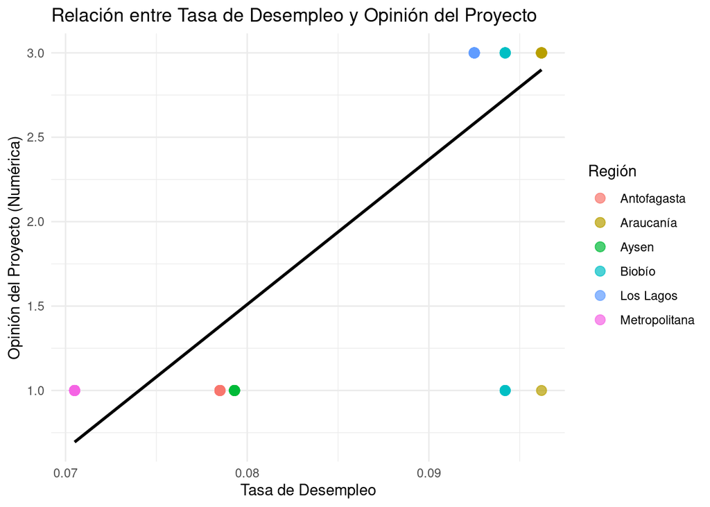

```r
# Convertir las opiniones a valores numéricos
df$Opinion_proyecto_num <- ifelse(df$Opinion_proyecto == "Negativa", 1,
                                  ifelse(df$Opinion_proyecto == "Neutral", 2,
                                         ifelse(df$Opinion_proyecto == "Positiva", 3, NA)))

# Cargar ggplot2
library(ggplot2)

# Crear el gráfico con ggplot2
p <- ggplot(df, aes(x = Tasa_desempleo, y = Opinion_proyecto_num, color = Región)) +
  geom_point(size = 3, alpha = 0.7) +
  geom_smooth(method = "lm", se = FALSE, color = "black") +
  theme_minimal() +
  labs(title = "Relación entre Tasa de Desempleo y Opinión del Proyecto",
       x = "Tasa de Desempleo", y = "Opinión del Proyecto (Numérica)",
       color = "Región")

# Mostrar el gráfico
print(p)
```

### **Análisis de la relación entre Población indígena, Tasa de Desempleo y Opinión del Proyecto**

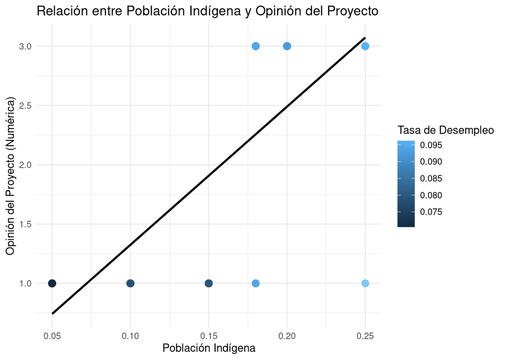

```r
## Gráfico de dispersión entre Pob_indígena y Opinión del Proyecto
ggplot(df, aes(x = Pob_indígena, y = Opinion_proyecto_num, color = Tasa_desempleo)) +
  geom_point(size = 3, alpha = 0.7) +
  geom_smooth(method = "lm", se = FALSE, color = "black") +
  theme_minimal() +
  labs(title = "Relación entre Población Indígena y Opinión del Proyecto", x = "Población Indígena",
       y = "Opinión del Proyecto (Numérica)", color = "Tasa de Desempleo")
```

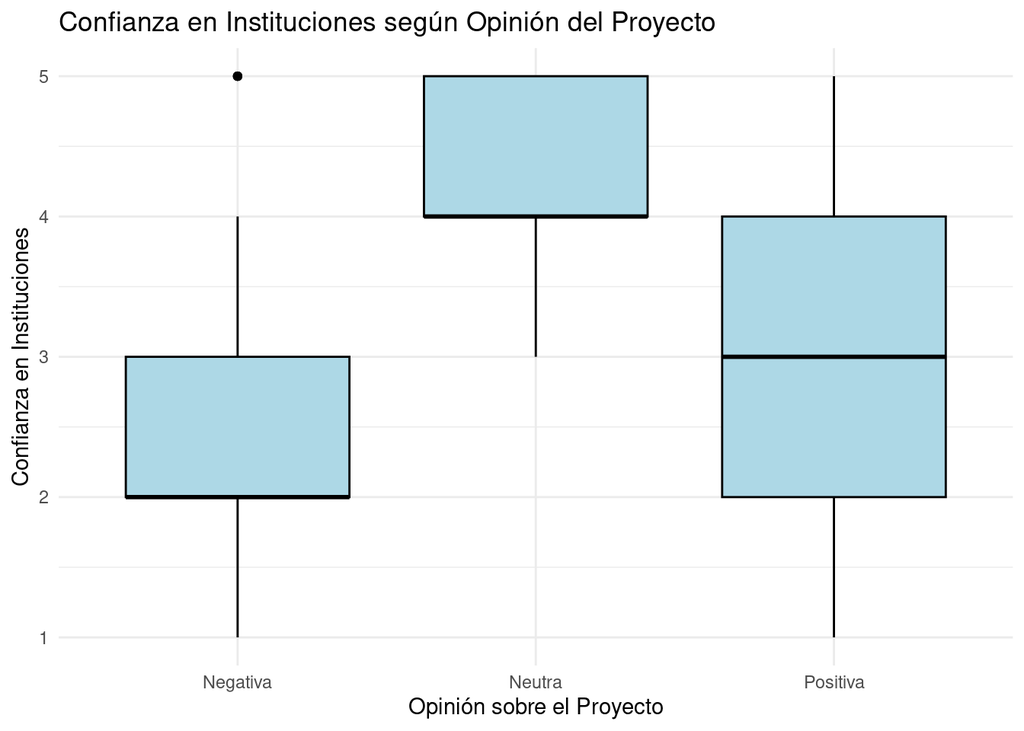

```r
ggplot(df, aes(x = Opinion_proyecto, y = Confianza_instituciones)) +
  geom_boxplot(fill = "lightblue", color = "black") +
  theme_minimal() +
  labs(title = "Confianza en Instituciones según Opinión del Proyecto",
       x = "Opinión sobre el Proyecto", y = "Confianza en Instituciones")
```

### **Organización comunitaria**

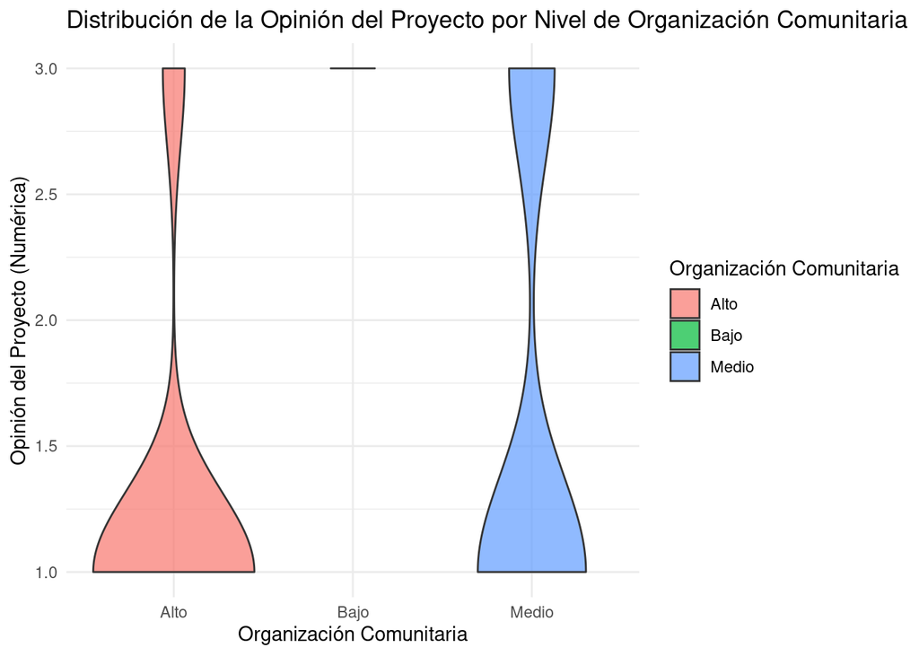

```r
## Gráfico de violín de Opinión del Proyecto en relación a la organización comunitaria.
ggplot(df, aes(x = Organización_comunitaria, y = Opinion_proyecto_num, fill = Organización_comunitaria)) +
  geom_violin(alpha = 0.7) +
  theme_minimal() +
  labs(title = "Distribución de la Opinión del Proyecto por Nivel de Organización Comunitaria",
       x = "Organización Comunitaria", y = "Opinión del Proyecto (Numérica)", fill = "Organización Comunitaria")
```

### **Conocimiento del proyecto**

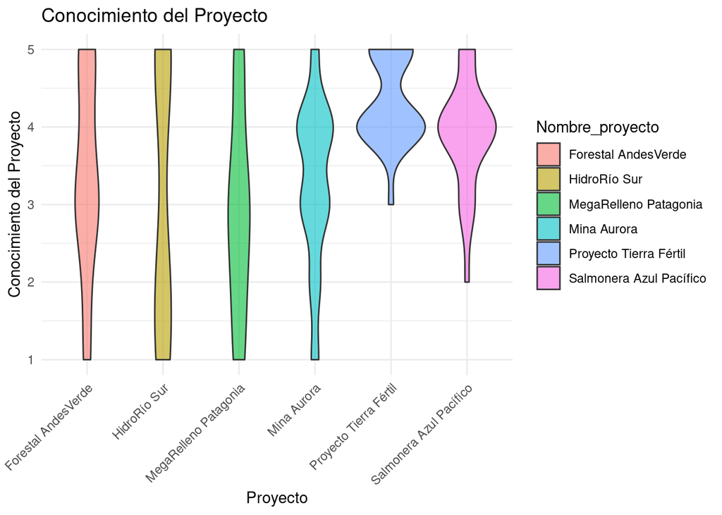

```r
## Relación entre Conocimiento del Proyecto y el Proyecto
ggplot(df, aes(x = Nombre_proyecto, y = Conocimiento_proyecto, fill = Nombre_proyecto)) +
  geom_violin(alpha = 0.6) +
  theme_minimal() +
  theme(axis.text.x = element_text(angle = 45, hjust = 1)) +
  labs(title = "Conocimiento del Proyecto", x = "Proyecto", y = "Conocimiento del Proyecto")
```

### **Prueba de Hipótesis:** Regresión Lineal para predecir la Opinión del Proyecto

#### Hipótesis:

##### H0 : Ninguna de las variables independientes tiene un efecto significativo sobre la opinión del proyecto.

##### H1: Al menos una de las variables independientes tiene un efecto significativo sobre la opinión del proyecto.

### **Regresión Lineal**

```r
modelo <- lm(Opinion_proyecto_num ~ Población_total_region + Pob_indígena + Porcentaje_rural +
               Tasa_desempleo + Confianza_instituciones + Num_actores_clave +
               Participación_ciudadana + Conocimiento_proyecto + Confianza_responsables,
             data = df)
summary(modelo)
```

```
##
## Call:
## lm(formula = Opinion_proyecto_num ~ Población_total_region +
##     Pob_indígena + Porcentaje_rural + Tasa_desempleo + Confianza_instituciones +
##     Num_actores_clave + Participación_ciudadana + Conocimiento_proyecto +
##     Confianza_responsables, data = df)
##
## Residuals:
##      Min       1Q   Median       3Q      Max
## -1.85503 -0.09510  0.06297  0.17358  0.64515
##
## Coefficients:
##                           Estimate Std. Error t value Pr(>|t|)
## (Intercept)             -6.147e+00  1.977e+00  -3.108  0.00241 **
## Población_total_region   1.127e-07  2.736e-08   4.119 7.51e-05 ***
## Pob_indígena             2.806e+00  6.916e+00   0.406  0.68571
## Porcentaje_rural         2.207e-01  1.374e+00   0.161  0.87265
## Tasa_desempleo           8.445e+01  3.164e+01   2.669  0.00880 **
## Confianza_instituciones  1.006e-01  4.254e-02   2.365  0.01982 *
## Num_actores_clave        9.125e-03  1.673e-02   0.545  0.58656
## Participación_ciudadana -2.019e-02  4.229e-02  -0.477  0.63408
## Conocimiento_proyecto   -2.844e-02  3.843e-02  -0.740  0.46090
## Confianza_responsables   5.819e-03  3.110e-02   0.187  0.85192
## ---
## Signif. codes:  0 '***' 0.001 '**' 0.01 '*' 0.05 '.' 0.1 ' ' 1
##
## Residual standard error: 0.4673 on 107 degrees of freedom
##   (20 observations deleted due to missingness)
## Multiple R-squared:  0.8002, Adjusted R-squared:  0.7834
## F-statistic: 47.61 on 9 and 107 DF,  p-value: < 2.2e-16
```

##### *Las variables más importantes para predecir la opinión sobre el proyecto son la población total de la región, la tasa de desempleo y la confianza en las instituciones. Otras variables como la población indígena, el porcentaje rural, el número de actores clave, la participación ciudadana, el conocimiento del proyecto y la confianza en los responsables no tienen un impacto significativo en la opinión sobre el proyecto en este modelo.*

## **Análisis de Variables de Impacto**

### **Riesgo de desplazamiento**

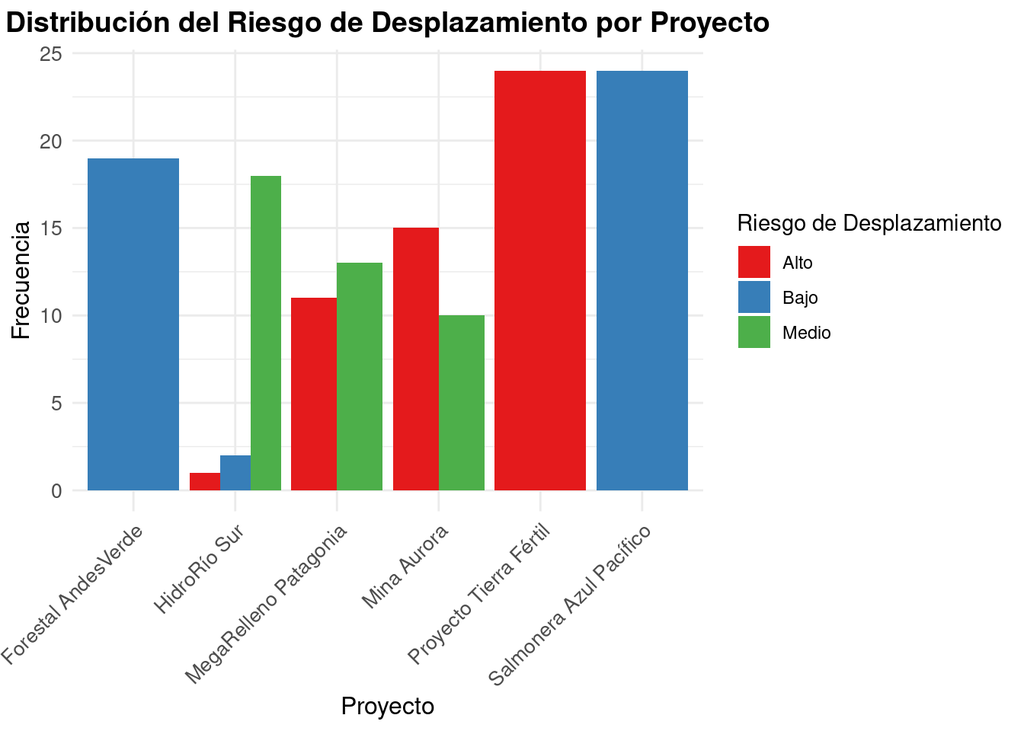

```r
## Gráfico de barras para Riesgo_desplazamiento por proyecto
ggplot(df, aes(x = Nombre_proyecto, fill = Riesgo_desplazamiento)) +
  geom_bar(position = "dodge") +
  theme_minimal() +
  labs(title = "Distribución del Riesgo de Desplazamiento por Proyecto",
       x = "Proyecto", y = "Frecuencia", fill = "Riesgo de Desplazamiento") +
  theme(axis.text.x = element_text(angle = 45, hjust = 1),
        plot.title = element_text(hjust = 0.5, size = 14, face = "bold"),
        axis.title = element_text(size = 12),
        axis.text = element_text(size = 10)) +
  scale_fill_brewer(palette = "Set1")
```

### **Cohesión social**

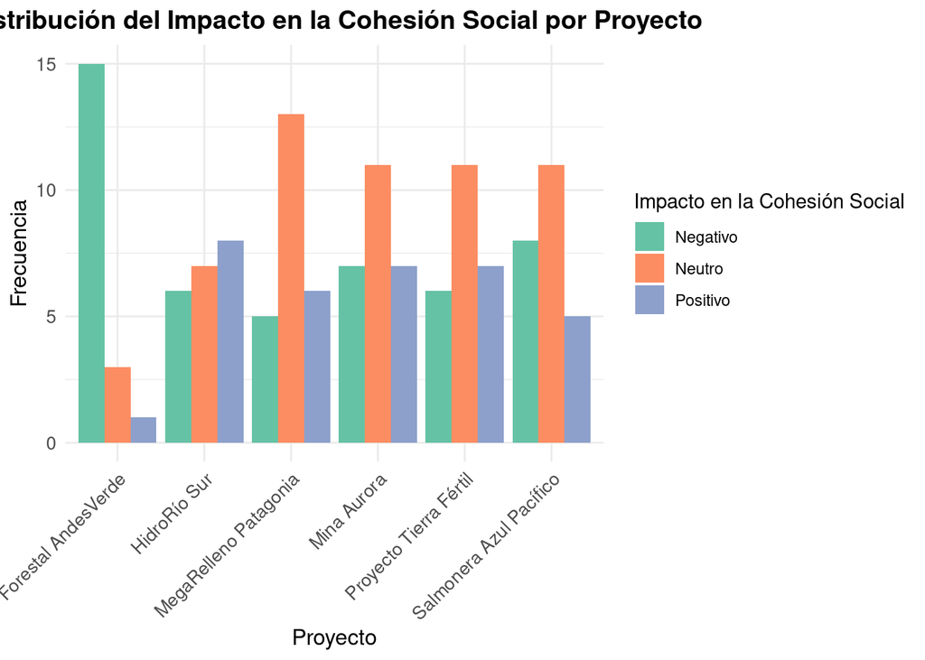

```r
## Gráfico de barras para Impacto_cohesión_social por proyecto
ggplot(df, aes(x = Nombre_proyecto, fill = Impacto_cohesión_social)) +
  geom_bar(position = "dodge") +
  theme_minimal() +
  labs(title = "Distribución del Impacto en la Cohesión Social por Proyecto",
       x = "Proyecto", y = "Frecuencia", fill = "Impacto en la Cohesión Social") +
  theme(axis.text.x = element_text(angle = 45, hjust = 1),
        plot.title = element_text(hjust = 0.5, size = 14, face = "bold"),
        axis.title = element_text(size = 12),
        axis.text = element_text(size = 10)) +
  scale_fill_brewer(palette = "Set2")
```

### **Percepción ambiental**

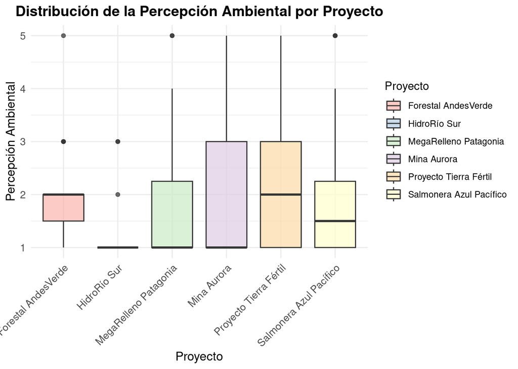

```r
# Gráfico de caja para Percepción_ambiental por proyecto
ggplot(df, aes(x = Nombre_proyecto, y = Percepción_ambiental, fill = Nombre_proyecto)) +
  geom_boxplot(alpha = 0.7) +
  theme_minimal() +
  labs(title = "Distribución de la Percepción Ambiental por Proyecto",
       x = "Proyecto", y = "Percepción Ambiental", fill = "Proyecto") +
  theme(axis.text.x = element_text(angle = 45, hjust = 1),
        plot.title = element_text(hjust = 0.5, size = 14, face = "bold"),
        axis.title = element_text(size = 12),
        axis.text = element_text(size = 10)) +
  scale_fill_brewer(palette = "Pastel1")
```

### **Conflictos potenciales**

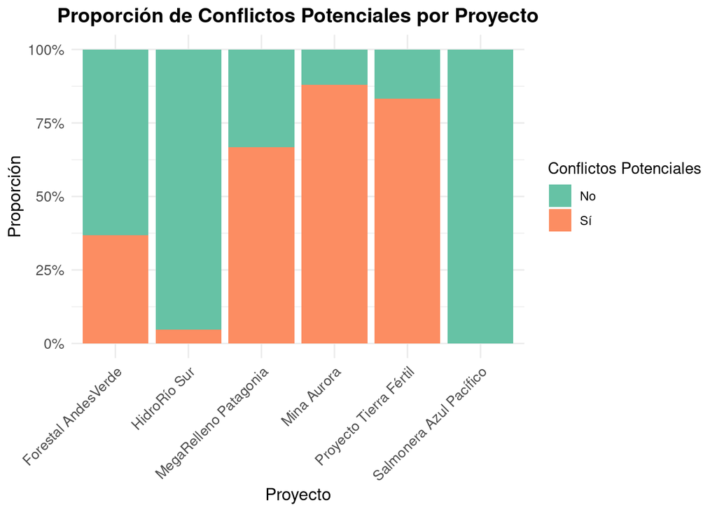

```r
## Gráfico de barras para Conflictos_potenciales por proyecto
ggplot(df, aes(x = Nombre_proyecto, fill = Conflictos_potenciales)) +
  geom_bar(position = "fill") +
  theme_minimal() +
  labs(title = "Proporción de Conflictos Potenciales por Proyecto",
       x = "Proyecto", y = "Proporción", fill = "Conflictos Potenciales") +
  theme(axis.text.x = element_text(angle = 45, hjust = 1),
        plot.title = element_text(hjust = 0.5, size = 14, face = "bold"),
        axis.title = element_text(size = 12),
        axis.text = element_text(size = 10)) +
  scale_y_continuous(labels = scales::percent_format()) +
  scale_fill_brewer(palette = "Set2")
```

### **Prueba de Hipótesis:** Correlación entre Variables de Impacto y Opinión del Proyecto

#### Hipótesis:

##### H0: No existe una correlación significativa entre las variables de impacto (Riesgo de desplazamiento, Impacto en la cohesión social, Cambio en el empleo local, Percepción ambiental, Impacto en la seguridad y servicios, Conflictos potenciales) y la opinión del proyecto.

##### H1: Existe una correlación significativa entre al menos una de las variables de impacto y la opinión del proyecto.

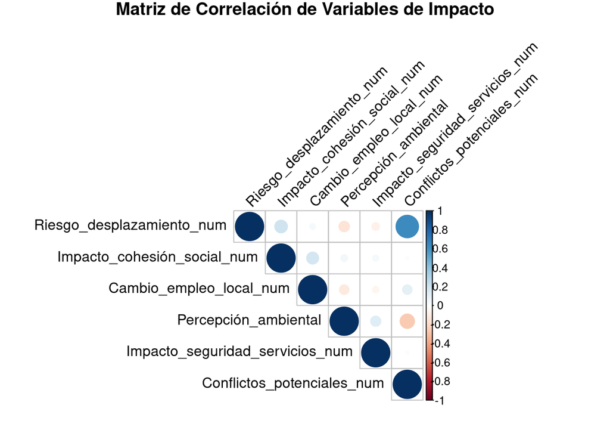

```r
## Correlación
# Convertir variables categóricas a numéricas para el análisis de correlación
df_cor <- df %>%
  mutate(
    Riesgo_desplazamiento_num = case_when(
      Riesgo_desplazamiento == "Alto" ~ 3,
      Riesgo_desplazamiento == "Medio" ~ 2,
      Riesgo_desplazamiento == "Bajo" ~ 1
    ),
    Impacto_cohesión_social_num = case_when(
      Impacto_cohesión_social == "Positivo" ~ 1,
      Impacto_cohesión_social == "Neutro" ~ 0,
      Impacto_cohesión_social == "Negativo" ~ -1
    ),
    Cambio_empleo_local_num = case_when(
      Cambio_empleo_local == "Aumento" ~ 1,
      Cambio_empleo_local == "Sin cambio" ~ 0,
      Cambio_empleo_local == "Disminución" ~ -1
    ),
    Impacto_seguridad_servicios_num = case_when(
      Impacto_seguridad_servicios == "Positivo" ~ 1,
      Impacto_seguridad_servicios == "Neutro" ~ 0,
      Impacto_seguridad_servicios == "Negativo" ~ -1
    ),
    Conflictos_potenciales_num = ifelse(Conflictos_potenciales == "Sí", 1, 0)
  )

# Calcular la matriz de correlación
correlaciones <- cor(df_cor[, c("Riesgo_desplazamiento_num", "Impacto_cohesión_social_num",
                                "Cambio_empleo_local_num", "Percepción_ambiental",
                                "Impacto_seguridad_servicios_num", "Conflictos_potenciales_num")])

# Visualizar la matriz de correlación
corrplot(correlaciones, method = "circle", type = "upper", tl.col = "black", tl.srt = 45,
         title = "Matriz de Correlación de Variables de Impacto", mar = c(0,0,1,0))
```

##### *La Prueba La correlación más fuerte es entre Riesgo_desplazamiento_num y Conflictos_potenciales_num (0.631), lo que indica una relación importante entre estas dos variables, la percepción ambiental también parece estar relacionada con los conflictos potenciales, aunque de manera negativa (-0.259). Las demás correlaciones son débiles o no significativas, lo que sugiere que no hay una relación lineal fuerte entre esas variables.*

### **Prueba de Significancia**

##### Para evaluar la significancia estadística de las correlaciones, se realizó una prueba de hipótesis para cada coeficiente de correlación utilizando la función cor.test().

```r
# Prueba de significancia para cada correlación
# Crear los resultados de la correlación
resultados_cor_impacto <- list()

variables_impacto <- c("Riesgo_desplazamiento_num", "Conflictos_potenciales_num")

for (var in variables_impacto) {
  test <- cor.test(df_cor[[var]], df_cor$Opinion_proyecto_num)
  resultados_cor_impacto[[var]] <- data.frame(
    Variable = var,
    Correlación = test$estimate,
    P_valor = test$p.value
  )
}

# Combinar los resultados en un solo dataframe
resultados_cor_impacto_df <- do.call(rbind, resultados_cor_impacto)

# Agregar la columna de significancia
resultados_cor_impacto_df <- resultados_cor_impacto_df %>%
  mutate(Significancia = ifelse(P_valor < 0.05, "Significativa", "No significativa"))

# Imprimir los resultados
print(resultados_cor_impacto_df)
```

```
##                                              Variable Correlación      P_valor
## Riesgo_desplazamiento_num   Riesgo_desplazamiento_num  -0.7871976 6.774577e-26
## Conflictos_potenciales_num Conflictos_potenciales_num  -0.8979831 8.259472e-43
##                            Significancia
## Riesgo_desplazamiento_num  Significativa
## Conflictos_potenciales_num Significativa
```

##### *Esta prueba indica que ambas correlaciones son negativas y significativas, lo que sugiere que los factores de riesgo de desplazamiento y conflictos potenciales influyen negativamente en la opinión sobre el proyecto. Dado que los p-valores, podemos rechazar la hipótesis nula (H₀) de que no existe correlación y afirmar que estos factores tienen una relación significativa con la opinión sobre el proyecto.*

##### *La correlación más fuerte es la de conflictos potenciales (-0.8980), lo que indica que este factor podría tener un impacto aún mayor en la percepción del proyecto.*

### **Análisis Variable Impacto calidad de vida**

```r
## Análisis variable Impacto calidad de vida por proyecto
tabla_calidad_vida <- table(df$Nombre_proyecto, df$Impacto_calidad_vida)


prop.table(tabla_calidad_vida, margin = 1) * 100
```

```
##
##                            Negativo    Neutro  Positivo
##   Forestal AndesVerde      0.000000 57.894737 42.105263
##   HidroRío Sur            71.428571 14.285714 14.285714
##   MegaRelleno Patagonia   41.666667 29.166667 29.166667
##   Mina Aurora             56.000000 16.000000 28.000000
##   Proyecto Tierra Fértil  91.666667  4.166667  4.166667
##   Salmonera Azul Pacífico 58.333333 12.500000 29.166667
```

### **Visualización Impacto en calidad de vida por proyecto**

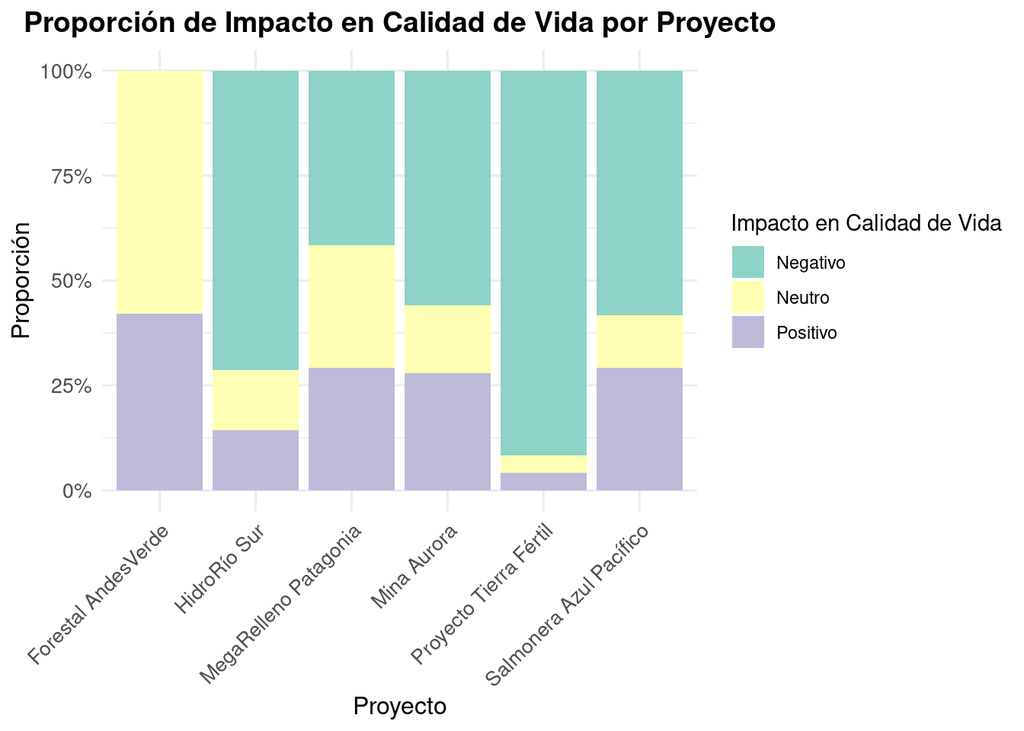

```r
ggplot(df, aes(x = Nombre_proyecto, fill = Impacto_calidad_vida)) +
  geom_bar(position = "fill") +
  scale_y_continuous(labels = scales::percent_format()) +
  theme_minimal() +
  labs(title = "Proporción de Impacto en Calidad de Vida por Proyecto",
       x = "Proyecto", y = "Proporción", fill = "Impacto en Calidad de Vida") +
  theme(axis.text.x = element_text(angle = 45, hjust = 1),
        plot.title = element_text(hjust = 0.5, size = 14, face = "bold"),
        axis.title = element_text(size = 12),
        axis.text = element_text(size = 10)) +
  scale_fill_brewer(palette = "Set3")
```

## **Análisis de Variables de Mitigación de riesgos**

### **Cumplimiento de compromisos**

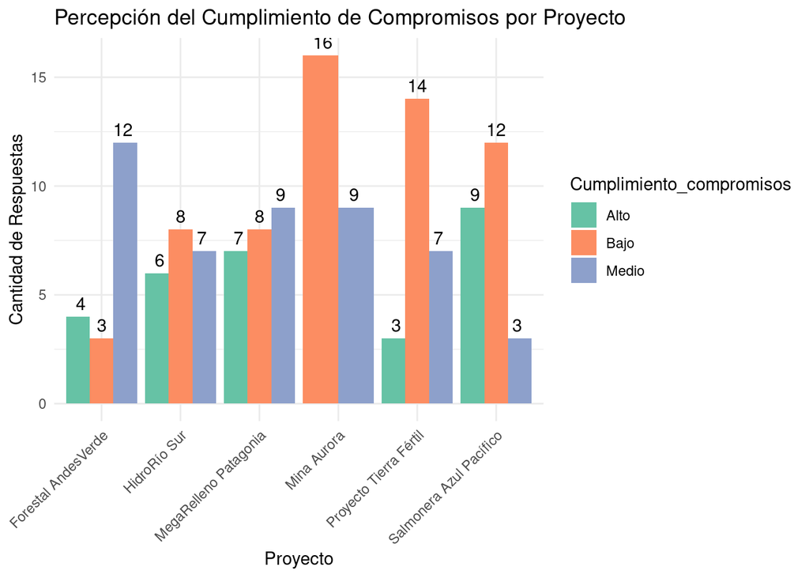

```r
## Gráfico de barras para la percepción del cumplimiento de compromisos por proyecto
ggplot(df, aes(x = Nombre_proyecto, fill = Cumplimiento_compromisos)) +
  geom_bar(position = "dodge") +
  theme_minimal() +
  labs(title = "Percepción del Cumplimiento de Compromisos por Proyecto",
       x = "Proyecto",
       y = "Cantidad de Respuestas") +
  theme(axis.text.x = element_text(angle = 45, hjust = 1)) +
  scale_fill_brewer(palette = "Set2") +
  geom_text(stat = 'count', aes(label = ..count..), position = position_dodge(0.8), vjust = -0.5)
```

### **Prueba de Hipotesis:** Relación entre Proyecto y Cumplimiento de compromisos.

#### Hipótesis:

##### H0: No hay relación entre el cumplimiento de compromisos y el nombre del proyecto.

##### H1: Existe una relación entre el cumplimiento de compromisos y el nombre del proyecto.

### **Prueba de Chi-cuadrado**

```r
tabla_proyecto_cumplimiento <- table(df$Nombre_proyecto, df$Cumplimiento_compromisos)
chi_result <- chisq.test(tabla_proyecto_cumplimiento)
```

```
## Warning in chisq.test(tabla_proyecto_cumplimiento): Chi-squared approximation
## may be incorrect
```

```r
# Mostrar el resultado de la prueba de chi-cuadrado
print(chi_result)
```

```
##
##  Pearson's Chi-squared test
##
## data:  tabla_proyecto_cumplimiento
## X-squared = 26.37, df = 10, p-value = 0.003274
```

##### *Dado el bajo p-valor (<0.05), hay una relación significativa entre el nombre del proyecto y el cumplimiento de compromisos. Es recomendable verificar los valores esperados y, si es necesario, usar la prueba exacta de Fisher para mayor precisión.*

### **Prueba de Monte Carlo**: Para corregir advertencia del test Chi-cuadrado

```r
fisher_result <- fisher.test(tabla_proyecto_cumplimiento, simulate.p.value = TRUE, B = 10000)  # 10,000 simulaciones
print(fisher_result)
```

```
##
##  Fisher's Exact Test for Count Data with simulated p-value (based on
##  10000 replicates)
##
## data:  tabla_proyecto_cumplimiento
## p-value = 0.0011
## alternative hypothesis: two.sided
```

### **Satisfacción con la Mitigación**

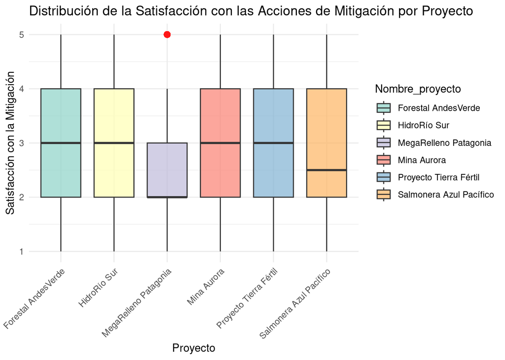

```r
ggplot(df, aes(x = Nombre_proyecto, y = Satisfacción_mitigación, fill = Nombre_proyecto)) +
  geom_boxplot(alpha = 0.7, outlier.colour = "red", outlier.shape = 16, outlier.size = 3) +
  theme_minimal() +
  labs(title = "Distribución de la Satisfacción con las Acciones de Mitigación por Proyecto",
       x = "Proyecto",
       y = "Satisfacción con la Mitigación") +
  theme(axis.text.x = element_text(angle = 45, hjust = 1)) +
  scale_fill_brewer(palette = "Set3")
```

### **Prueba de Hipótesis:**ANOVA para comparar satisfacción con mitigación de Proyectos

#### Hipótesis:

##### H0: La satisfacción con la mitigación no varía significativamente entre los proyectos.

##### H1: La satisfacción con la mitigación varía significativamente entre los proyectos.

### **Prueba ANOVA**

```r
anova_satisfaccion <- aov(Satisfacción_mitigación ~ Nombre_proyecto, data = df)
summary(anova_satisfaccion)
```

```
##                  Df Sum Sq Mean Sq F value Pr(>F)
## Nombre_proyecto   5   2.34  0.4671   0.276  0.926
## Residuals       131 221.94  1.6942
```

##### *No hay diferencias estadísticamente significativas en la satisfacción con la mitigación entre los proyectos. La variación observada en la satisfacción parece deberse al azar y no a diferencias reales entre los proyectos.*

### **Verificar los supuestos del ANOVA:** de homogeneidad de varianzas

#### Hipótesis:

##### H0: Las varianzas son homogéneas entre los grupos.

##### H1: Las varianzas no son homogéneas entre los grupos.

### **Prueba de Levene**

```r
#Prueba de Levene
leveneTest(Satisfacción_mitigación ~ Nombre_proyecto, data = df)
```

|  | Df | F value | Pr(>F) |
| --- | --- | --- | --- |
| group | 5 | 0.2982991 | 0.9130745 |
|  | 131 | NA | NA |

##### *No hay evidencia suficiente para afirmar que las varianzas sean diferentes entre los grupos. Por lo tanto, se cumple el supuesto de homogeneidad de varianzas.*

### **Prueba de normalidad:**

##### Hipótesis:

##### H0: Los residuos siguen una distribución normal.

##### H0: Los residuos no siguen una distribución normal.

### **Test de Shapiro-Wilk**

```r
shapiro.test(residuals(anova_satisfaccion))
```

```
##
##  Shapiro-Wilk normality test
##
## data:  residuals(anova_satisfaccion)
## W = 0.94259, p-value = 1.977e-05
```

### **Prueba no paramétrica Kruskal-Wallis**

```r
kruskal.test(Satisfacción_mitigación ~ Nombre_proyecto, data = df)
```

```
##
##  Kruskal-Wallis rank sum test
##
## data:  Satisfacción_mitigación by Nombre_proyecto
## Kruskal-Wallis chi-squared = 1.4611, df = 5, p-value = 0.9175
```

##### *Tanto el ANOVA como la prueba de Kruskal-Wallis indican que no hay diferencias significativas en la satisfacción con la mitigación entre los proyectos.Esto sugiere que, en promedio, los proyectos tienen niveles de satisfacción similares en cuanto a la mitigación, y no sería necesario realizar intervenciones específicas para cada proyecto en este aspecto.*

### **Prueba de Hipótesis:** ANOVA para comparar satisfacción con la mitigación según el cumplimiento de compromisos.

#### Hipótesis:

##### H0: La satisfacción con la mitigación no varía significativamente según el cumplimiento de compromisos.

##### H1: La satisfacción con la mitigación varía significativamente según el cumplimiento de compromisos.

```r
anova_mitigacion <- aov(Satisfacción_mitigación ~ Cumplimiento_compromisos, data = df)
summary(anova_mitigacion)
```

```
##                           Df Sum Sq Mean Sq F value Pr(>F)
## Cumplimiento_compromisos   2   1.74  0.8693   0.523  0.594
## Residuals                134 222.54  1.6607
```

##### *Se acepta la Hipótesis Nula: El cumplimiento de compromisos no es un factor determinante en la satisfacción con la mitigación.*

### **Prueba de Levene:** Análisis homogeneidad de varianzas

```r
# Prueba de Levene
leveneTest(Satisfacción_mitigación ~ Cumplimiento_compromisos, data = df)
```

|  | Df | F value | Pr(>F) |
| --- | --- | --- | --- |
| group | 2 | 0.4338375 | 0.6489244 |
|  | 134 | NA | NA |

##### *Se cumple el supuesto de homogeneidad de varianzas*

### **Análisis de densidad de valores dentro de cada categoría de cumplimiento**

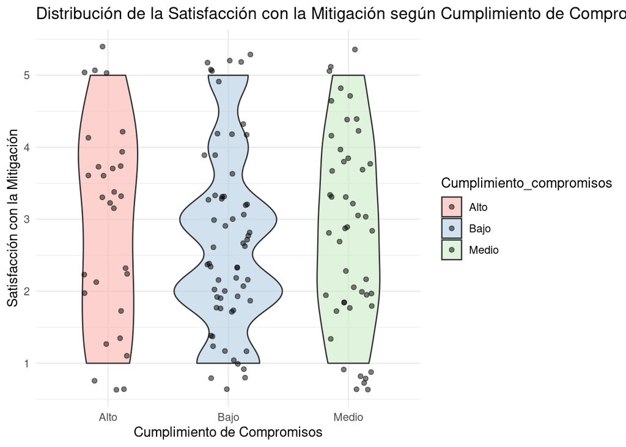

```r
#Gráfico de violín
ggplot(df, aes(x = Cumplimiento_compromisos, y = Satisfacción_mitigación, fill = Cumplimiento_compromisos)) +
  geom_violin(alpha = 0.6) +
  geom_jitter(color = "black", width = 0.2, alpha = 0.5) +
  theme_minimal() +
  labs(title = "Distribución de la Satisfacción con la Mitigación según Cumplimiento de Compromisos",
       x = "Cumplimiento de Compromisos",
       y = "Satisfacción con la Mitigación") +
  scale_fill_brewer(palette = "Pastel1")
```

##### *Existe una alta variabilidad en la satisfacción, particularmente en quienes manifiestan un bajo cumplimiento de compromisos*

# **Conclusiones:**

##### - *Se recomienda fortalecer la participación ciudadana, mejorar la comunicación sobre los compromisos asumidos y adaptar las estrategias de mitigación a las necesidades específicas de cada comunidad.*

##### - *Implementar estas recomendaciones contribuirá a reducir la incertidumbre y aumentar la aceptación de los proyectos, garantizando un mayor impacto positivo en la población.*